# Number of growing seasons

Quality check of the crop masks

Guido Fioravanti

2023-02-21

### Potential inconsistencies identified by Alfred

Spatial distribution of potential inconsistencies in the crop masks. The North of Spain presents many potential errors in the crop masks…pixels which randomly switch on and off…

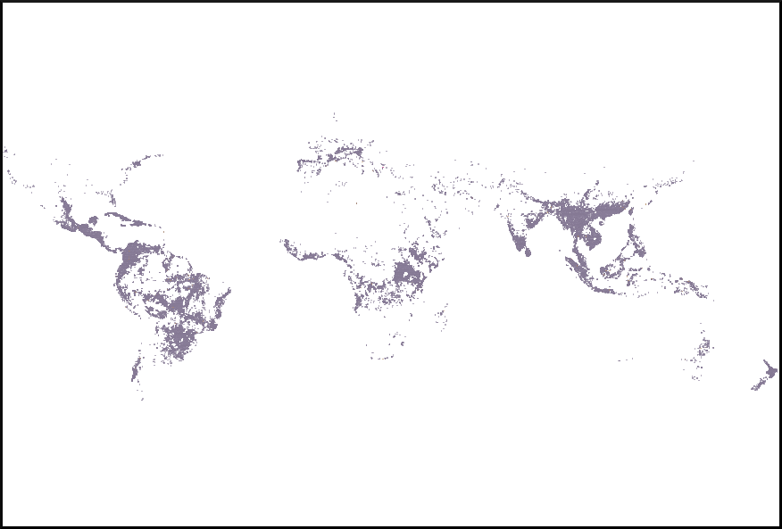

### ASAP Crop Masks (Guido’s review)

Focus on Spain. The following map shows the number of growing seasons in Spain. To calculate the number of growing seasons, my program looks for “active crop” pixels which are contiguous in time.

**Surprisingly, many pixels in Spain have two growing seasons**…..but…..check the plots below… my program does not consider that a growing season can start in Autumn and terminate in winter/spring of the next year…

**SPOILER**: to check whether the crop masks are affected by pixels which switch on and off, we must look at their temporal profile (see the plots below).

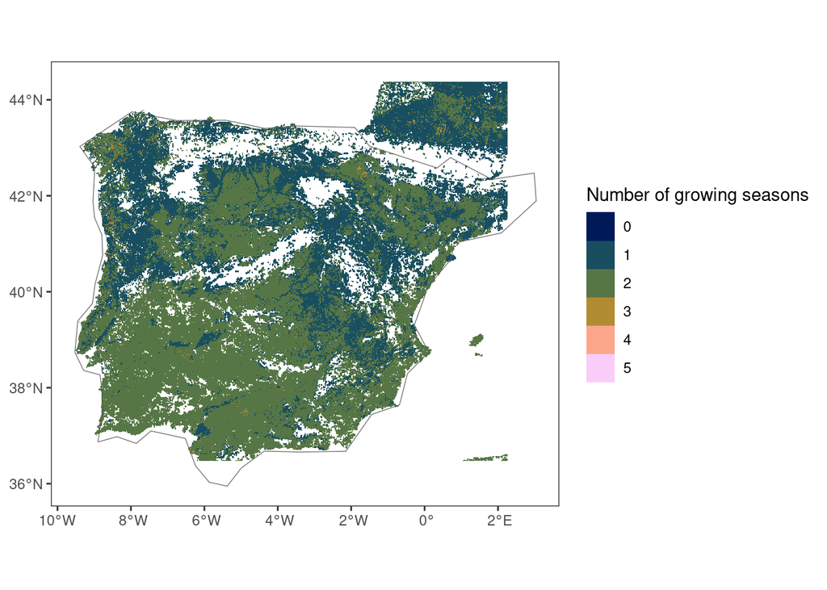

### Number of pixels per growing seasons (frequency of the number of the growing seasons)

Most of the pixel have 1 or 2 growing seasons … (**more exactly, my naive approach R program returns a large number of pixels with 2 growing seasons….**)

```
##
##      0      1      2      3      4      5
##      1 215105 328047   4614    168      2
```

### Pixels with 1 growing season

Simplest case: the crop growing season starts and terminates in the middle of the year. In this case, counting the number of the growing seasons is quite straightforward (we look for contiguous 0es to detect where the 1s pixels are).

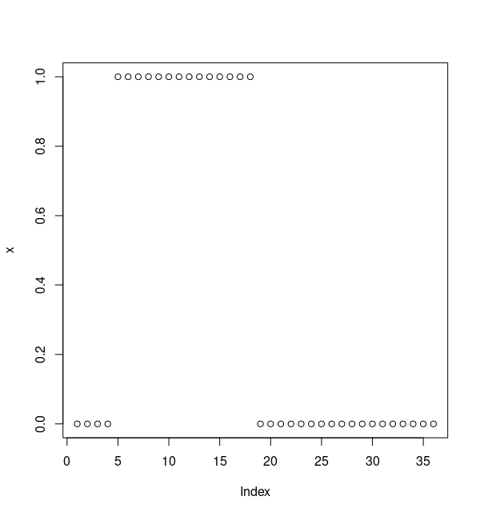

### Pixels with 2 growing season

In Europe, we expect that most of the pixel have just 1 growing season (see, for instance, the ASAP crop calendars). Why so many pixels with two growing seasons? Are there pixels which switch on and off?

Actually, “2 growing seasons” corresponds to a tricky situation: **the growing season starts at the end of the year and terminates the following year**. This situation is clearly described in the ASAP report about Crop Masks.

MESSAGE:

- **My programs “sees” two growing seasons but it is is just one growing season!!!**
- **To identify problems in the crop masks, we must see the temporal series of the crop pixels…looking for pixels which “switch on/off” can give misleading results**

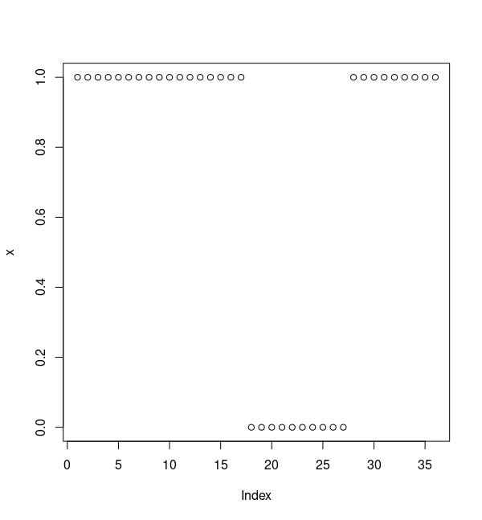

### Pixels with 3 growing season

**Dubious situation: one or two growing seasons?** The isolated pixel is a “missed” active crop pixel? I don’t know, but the spatial distribution of these pixels says is reassuring. These pixels are sparse in space.

Go back to the first picture in this document and focus on Spain: in that picture, many pixels in the North of Spain are identified as potentially wrong because they “switch on and off”. My results suggest that we can rely on the crop masks. Dubious situations like this one affect few pixels…and it is not easy to say what is happening…. **In countries where there are two growing seasons (like in South Asia), the analysis of the crop masks quality need careful analysis…**-

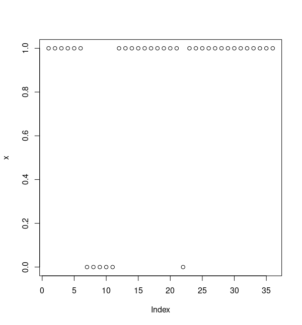

Remember: two growing seasons correspond to situations where one growing season covers two years.

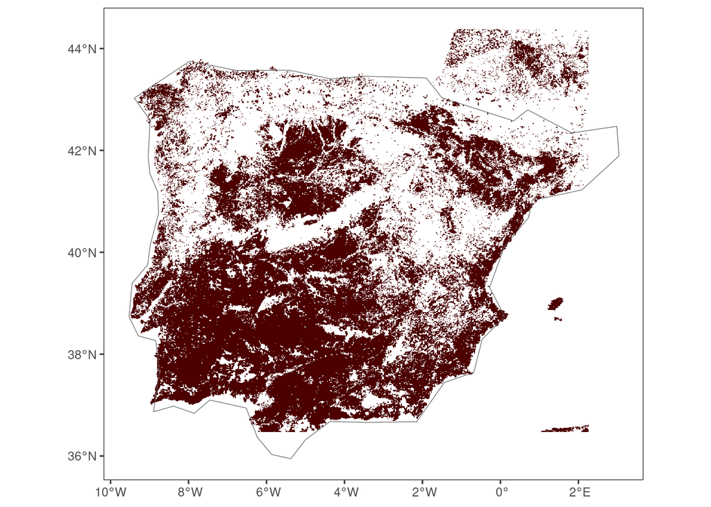

## Spatial distribution of the pixels with 3 growing seasons

Compare with the first picture of the document..these points are scattered…

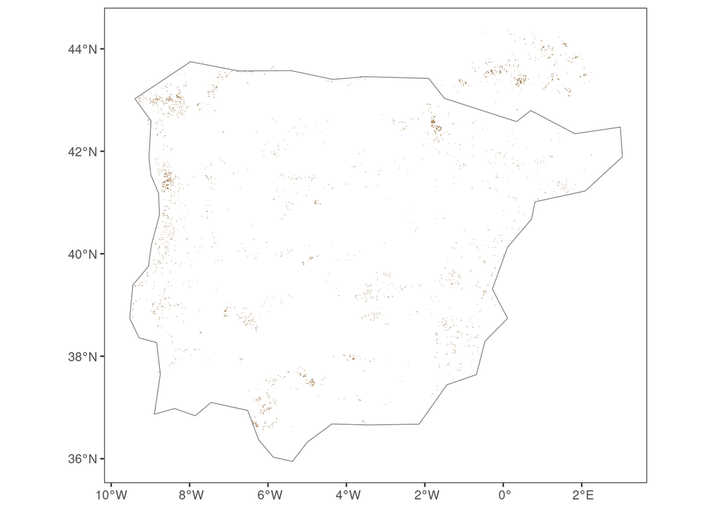

## Spatial distribution of the pixels with 4 or 5 growing seasons

[figure not shown]